# Conservation Tillage data from USDA

Ellen

2022-09-20

The existing **$current_conservation_tillage_county** tables gives the percent of agricultural land that is managed with conservation tillage by county.

```r
ARCHIVE_current_conservation_tillage_county <- tibble::tribble(
  ~co_name, ~current_conservation_tillage_percent,
  "Anoka", 0.08815018,
  "Carver", 0.28413933,
  "Dakota", 0.10034745,
  "Hennepin", 0.04441539,
  "Ramsey", 0.13178295,
  "Scott", 0.01036328,
  "Washington", 0.10532122
)
```

These numbers seemed suspiciously low to me. For instance, check out [this high level report from the USDA on conservation tillage numbers](https://www.ers.usda.gov/webdocs/publications/90201/eib197_summary.pdf?v=8320.9); you’ll see that across the US, over 60% of corn is in conservation tillage and over 70% of beans are in conservation tillage (and these are the two main crops grown in MN). So I went directly to the USDA’s data (via API), and got some pretty different numbers.

**I am recommending that the GHG database values be updated to match USDA Census values for conservation tillage.**

The processed data is saved as `/data/usda_data.rda`, but can also be directly downloaded via the USDA API.

1. Get an API key from USDA: https://quickstats.nass.usda.gov/api
2. Enter in the console: `usethis::edit_r_environ()`
3. When the `.Renviron` file comes up in the editor, type: `USDA_KEY="KEY GOES HERE, INSIDE QUOTES"`
4. Save and close the `.Renviron` file.
5. Restart R.

```r
process_usda <- FALSE

if (process_usda == TRUE) {
  mn_conservation_tillage_fxn <- function(.county) {
    raw <- httr::GET(paste0(
      "http://quickstats.nass.usda.gov/api/api_GET/?key=",
      Sys.getenv("USDA_KEY"),
      "&source_desc=CENSUS",
      "&commodity_desc=PRACTICES",
      "&class_desc=LAND%20USE,%20CROPLAND",
      "&unit_desc=ACRES",
      "&agg_level_desc=COUNTY", # STATE",
      "&county_name=", .county, # WASHINGTON",
      "&domain_desc=TOTAL",
      "&year=2017",
      "&state_alpha=MN&format=JSON"
    ))

    parsed <- jsonlite::fromJSON(httr::content(x = raw, as = "text"))$data

    return(parsed)
  }

  mn_conservation_tillage_raw <-
    mn_conservation_tillage_fxn("ANOKA") %>%
    bind_rows(mn_conservation_tillage_fxn("CARVER")) %>%
    bind_rows(mn_conservation_tillage_fxn("DAKOTA")) %>%
    bind_rows(mn_conservation_tillage_fxn("HENNEPIN")) %>%
    bind_rows(mn_conservation_tillage_fxn("RAMSEY")) %>%
    bind_rows(mn_conservation_tillage_fxn("SCOTT")) %>%
    bind_rows(mn_conservation_tillage_fxn("WASHINGTON"))

  usda_data <- mn_conservation_tillage_raw %>%
    mutate(Value = as.numeric(gsub(",", "", Value))) %>%
    filter(prodn_practice_desc != "COVER CROP PLANTED, (EXCL CRP)") %>%
    select(county_name, prodn_practice_desc, Value) %>%
    group_by(county_name) %>%
    mutate(
      total_acres = sum(Value),
      percent = Value / total_acres
    ) %>%
    mutate(tillage = if_else(prodn_practice_desc %in%
      c(
        "CONSERVATION TILLAGE, (EXCL NO-TILL)",
        "CONSERVATION TILLAGE, NO-TILL"
      ),
    "conservation tillage", "conventional"
    )) %>%
    group_by(county_name, tillage) %>%
    summarise(current_conservation_tillage_percent = sum(percent), .groups = "keep") %>%
    filter(tillage == "conservation tillage") %>%
    mutate(
      source = "USDA API",
      co_name = stringr::str_to_title(county_name)
    ) %>%
    ungroup() %>%
    select(co_name, current_conservation_tillage_percent)
  save(usda_data, file = paste0(here::here(), "/data/usda_data.rda"))
} else {
  load(paste0(here::here(), "/data/usda_data.rda"))
}
```

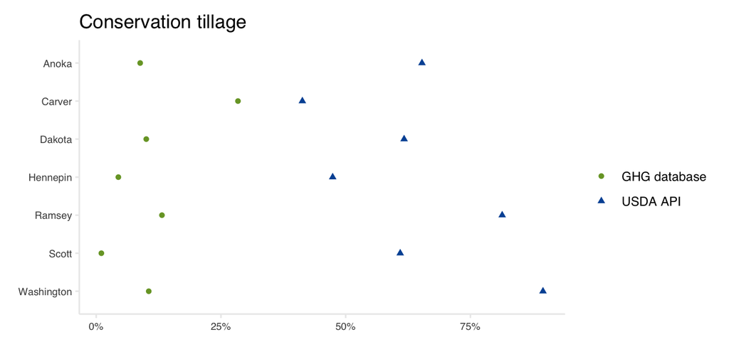

```r
usda_data %>%
  mutate(source = "USDA API") %>%
  bind_rows(ARCHIVE_current_conservation_tillage_county %>% # land_use_data$current_conservation_tillage_county %>%
    mutate(source = "GHG database")) %>%
  ggplot(aes(
    y = forcats::fct_rev(co_name),
    x = current_conservation_tillage_percent,
    col = source, pch = source
  )) +
  geom_point() +
  scale_color_manual(values = c(councilR::colors$cdGreen, councilR::colors$councilBlue)) +
  theme_council_open() +
  labs(y = "", x = "", title = "Conservation tillage", col = "", pch = "") +
  scale_x_continuous(labels = scales::percent)
```